# Seminar 10: Descriptive statistics

## 1. Data (Id is the average of the member’s no. in the P&S list)

### Task: Generate your data

This is a sample of size $n=1000$ combined from two samples of size $500$ from the normal distributions $N(\mu_k,\sigma_k^2)$ with $\mu_1 = Id$, $\sigma_1 = 3$ and $\mu_2 = -2$, $\sigma_2 = Id$

Hint: you can use $\texttt{mean = c}(\mu_1,\mu_2)$ and $\texttt{sd = c}(\sigma_1,\sigma_2)$

```r
id = (35+67+1)/3
# your code here
n <- 1000
sigma_1 <- 3
sigma_2 <- id
mu_1 <- id
mu_2 <- -2
mean <- c(mu_1, mu_2)
sd <- c(sigma_1, sigma_2)
my.data <- rnorm(n, mean, sd)
summary(my.data)
```

```
     Min.   1st Qu.    Median      Mean   3rd Qu.      Max.
-114.7023    0.2138   31.9204   17.8449   35.6107  112.8029
```

## 2. Visualise the data

### Task: Draw the histogram of the data, empirical density, and empirical cdf. Comment on whether the data are close to a normal one

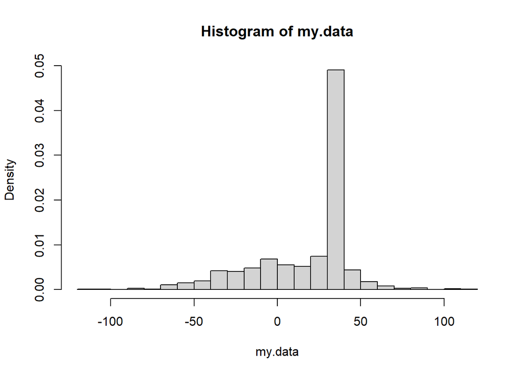

```r
# draw histogram
hist(my.data, breaks = 30, probability = T)
```

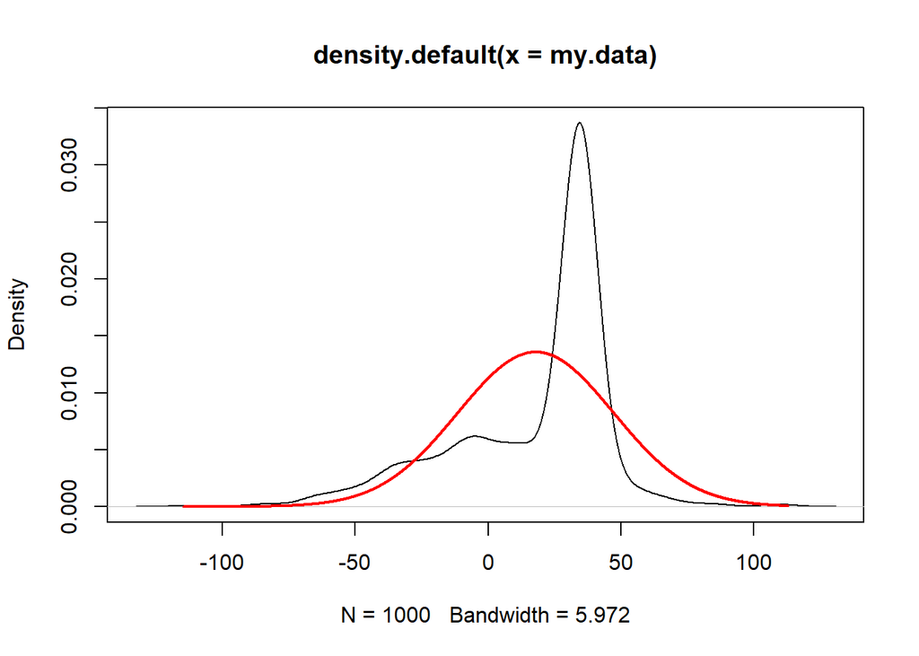

```r
# superimpose empirical density
plot(density(my.data))
# superimpose normal density
x <- seq(min(my.data), max(my.data), by = .01)
lines(x, dnorm(x, mean = mean(my.data), sd = sd(my.data)), col = "red", lwd = 2)
```

```r
# plot(ecdf(my.data))
# lines(my.data, pnorm(my.data, mean = mean(my.data), sd = sd(my.data)), col ="red", lwd = 2)
```

### Plot ecdf

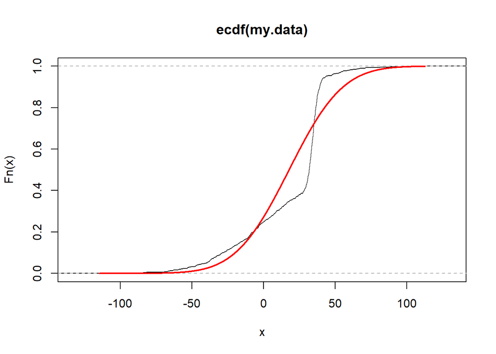

```r
# plot ecdf
plot(ecdf(my.data))
# superimpose cdf for standard normal
x <- seq(min(my.data), max(my.data), by = .01)
lines(x, pnorm(x, mean = mean(my.data), sd = sd(my.data)), col = "red", lwd = 2)
```

```r
# calculate maximal difference
max(abs(ecdf(my.data)(x) - pnorm(x, mean = mean(my.data), sd = sd(my.data))))
```

```
[1] 0.2408733
```

## 3. Skewness and kurtosis of the data

**Skewness** is defined as
$$\mathsf{E} \left[\left({\frac {X-\mu }{\sigma
}}\right)^{3}\right]={\frac {\mu _{3}}{\sigma ^{3}}}={\frac {\mathsf{E}
\left[(X-\mu )^{3}\right]}{\ \ \ (\mathsf{E} \left[(X-\mu
)^{2}\right])^{3/2}}}$$

Positive skewness means the data have longer right tail and then the mean value $\mathsf{E}(X)$ is greater than the median

**Kurtosis** is defined as
$$\mathsf{E} \left[\left({\frac {X-\mu }{\sigma
}}\right)^{4}\right]={\frac {\mu _{4}}{\sigma ^{4}}}={\frac {\mathsf{E}
\left[(X-\mu )^{4}\right]}{\ \ \ (\mathsf{E} \left[(X-\mu
)^{2}\right])^{2}}}$$

For a standard normal distribution, the kurtosis is $3$. If we get a larger value, then more data are concentrated ner the mean, and the empirical density is more steep

```r
# skewness
skewness <- function(x) {
  m3 <- mean((x - mean(x))^3)
  m2 <- mean((x - mean(x))^2)
  return(m3 / m2^(3 / 2))
}

skewness_calculated <- skewness(my.data)
print(skewness_calculated)
```

```
[1] -1.113201
```

```r
if (skewness_calculated > 0) {
  print("The data are positively skewed - the tail is longer on the right side")
} else if (skewness_calculated < 0) {
  print("The data are negatively skewed - the tail is longer on the left side")
} else {
  print("The data are symmetrically distributed")
}
```

```
[1] "The data are negatively skewed - the tail is longer on the left side"
```

```r
# kurtosis
kurtosis <- function(x) {
  m4 <- mean((x - mean(x))^4)
  m2 <- mean((x - mean(x))^2)
  return(m4 / m2^2)
}

kurtosis_calculated <- kurtosis(my.data)
print(kurtosis_calculated)
```

```
[1] 4.288181
```

```r
if (kurtosis_calculated > 3) {
  print("The data is more concentrated near the mean")
} else if (kurtosis_calculated < 3) {
  print("The data is more dispersed")
} else {
  print("The data is normally distributed")
}
```

```
[1] "The data is more concentrated near the mean"
```

## 4. Percentiles

### For q= 0.1,…,0.9 calculate sample q-percentiles manually (i.e. by sorting the data and picking the corresponding values) and by using percentile

```r
# sort the data
sorted_data <- sort(my.data)

# calculate sample q-percentiles manually
q <- seq(0.1, 0.9, 0.1)
print(q)
```

```
[1] 0.1 0.2 0.3 0.4 0.5 0.6 0.7 0.8 0.9
```

```r
percentiles <- q * n
percentiles <- round(percentiles)
percentiles <- percentiles + 1
percentiles <- sorted_data[percentiles]
print(percentiles)
```

```
[1] -27.735643  -7.209016   9.030343  28.374394  31.929464  33.517275  34.923801
[8]  36.515084  39.262460
```

```r
# calculate sample q-percentiles by using percentile
quantile <- quantile(my.data, q)
print(quantile)
```

```
       10%        20%        30%        40%        50%        60%        70%
-27.845866  -7.239614   8.983865  28.367955  31.920404  33.504072  34.918596
       80%        90%
 36.513437  39.233643
```

## 5. Sample mean and sample standard error vs the theoretical ones

### What is the theoretical expected value of the random variable considered? What is the variance? Compare them to the sample values; explain the difference in the variance

$$\mu_{th} = E(W|W=x)*P(W=x) +
E(W|W=y)*P(W=y) =\frac{k*E(X) + k*E(Y)}{2k} = \frac{E(X) +E(Y)}{2} =
0.5(\mu_1 + \mu_2)$$

$$Var_{th} = Var(W) = E(W^2) - E(W)^2$$
$$E(W^2) = E(W^2|W=x)*P(W=x) +
E(W^2|W=y)*P(W=y) =0.5*(E(X^2) + E(Y^2)) = 0.5*(Var(X) + E(X)^2 +
Var(X) + E(X)^2)$$
$$E(W^2)
=0.5(\sigma_1^2 + \sigma_2^2 + \mu_1^2 + \mu_2^2)$$
$$Var_{th} = Var(W) = E(W^2) - E(W)^2 =
0.5(\sigma_1^2 + \sigma_2^2 + \mu_1^2 + \mu_2^2) - \frac{\mu_1^2 +
\mu_2^2 + 2\mu_1\mu_2}{4}$$

$$Var_{th} = 0.5(\sigma_1^2 + \sigma_2^2)
+ (\mu_1 - \mu_2)^2/4$$

```r
# your code here
# theoretical expected value and variance
theorexp <- sum(mean / 2)
theorexp
```

```
[1] 16.16667
```

```r
theorvar <- (sigma_1**2 + sigma_2**2) / 2 + 0.25 * (mu_1 - mu_2)**2
theorvar
```

```
[1] 923.9167
```

```r
# sample mean and sample variance
mean(my.data)
```

```
[1] 17.84486
```

```r
var(my.data)
```

```
[1] 863.1524
```

## 6. k-sigma rule

### Calculate the fraction of the data that are within $k\sigma$ of the sample mean for $k=1,2,3$. Do we get the result expected? Why or why not?

```r
# Calculate the fraction of the data that are within $k\sigma$ of the sample mean for $k=1,2,3$. Do we get the result expected? Why or why not?

m <- mean(my.data)
s <- sd(my.data)
mean(abs(my.data - m) < s)
```

```
[1] 0.787
```

```r
mean(abs(my.data - m) < s * 2)
```

```
[1] 0.944
```

```r
mean(abs(my.data - m) < s * 3)
```

```
[1] 0.991
```